# Project Final Submission

### Step 1a: Planning

#### Identify the information in the file your program will read

Describe (all) the information that is available. Be sure to note any surprising or unusual features. (For example, some information sources have missing data, which may be blank or flagged using values like -99, NaN, or something else.)

```
The available information includes:
```

- **property information**: including id, which is the unique integer that identities each airbnb property in the area. As well as property type and room type.
- **location of the property**: including neighbourhood, which is the neighbourhood name where the property is located. As well as city, state, zipcode, and country.
- **accommodates**: is an integer representing the maximum number of guests each property can accommodate per night. It is ranging from 1 to 20 inclusively.
- **price**: the total price per night of the property. The price is an integer ranging from 0 to 10000 inclusively.
- **review scores rating**: the overall guest review score for each Netherland Airbnb property. Review scores represent the overall rate of satisfaction of guests regarding the Airbnb properties (the higher the better). The scores are integers ranging from 0 to 100 inclusive.
- **review scores location**: the guest review score for each Netherland Airbnb property. Review scores represent the rate of satisfaction of guests regarding the Airbnb properties’ location (the higher the score means the location of the property is more convenient). The scores are integers ranging from 0 to 10 inclusively.

### Step 1b: Planning

#### Brainstorm ideas for what your program will produce

#### Select the idea you will build on for subsequent steps

You must brainstorm at least three ideas for graphs or charts that your program could produce and choose the one that you'd like to work on. You can choose between a line chart, histogram, bar chart, scatterplot, or pie chart.

If you would like to change your project idea from what was described in the proposal, you will need to get permission from your project TA. This is intended to help ensure that your new project idea will meet the requirements of the project. Please see the project proposal for things to be aware of when communicating with your project TA.

- A line chart shows the average review scores rating for each neighbourhood
- A pie chart shows different property type of all airbnb properties
- A bar chart shows the number of reviews for a given neighbourhood
- A bar chart shows the average review scores location for each neighbourhood
- A bar chart shows the average price per accommodated guest for each neighbourhood

We will focus on the last one.

### Step 1c: Planning

#### Write or draw examples of what your program will produce

You must include a **hand-drawn image** that shows what your chart or plot will look like. You can insert an image using Edit -> Insert Image.

Insert your image into this cell.

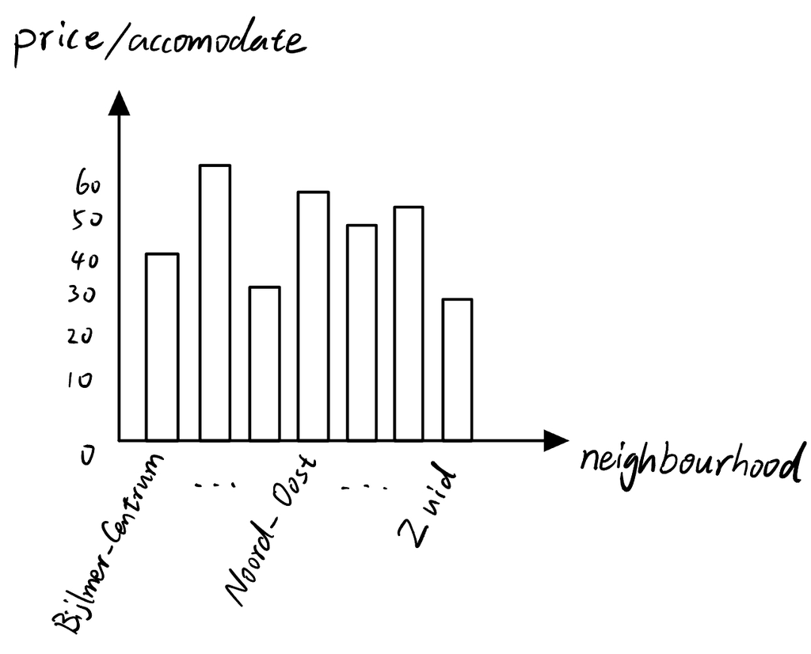

The bar chart should show the price per guest for all the neighbourhoods, with:

- y-axis: calculated price per guest for each Airbnb property using this formula: price/accommodates
- x-axis: taken from "neighbourhood_cleansed", shows all the neighbourhoods in the dataset.
- Possible function call: find_avg_price("airbnb_cleaned.csv", Neighbourhood.Zuid)
- Possible output: 31 (average price per guest for airbnb property in the Neighbourhood.Zuid)

### Step 2a: Building

#### Document which information you will represent in your data definitions

Before you design data definitions in the code cell below, you must explicitly document here which information in the file you chose to represent and why that information is crucial to the chart or graph that you'll produce when you complete step 2c.

We will need to use the following information from the data file:

- id (9th column, which is index 8)
- neighbourhood_cleansed (10th column, which is index 9)
- accommodates (20th column, which is index 19)
- price (25th column, which is index 24)

We need price and accommodates to calculate price per guest (price/accommodate = price / accommodates) as we are interest in the price per guest for each neighbourhoods, we also need neighbourhood_cleansed for all the neighbourhoods that each Airbnb properties are located in.

#### Design the data definitions

```python
from cs103 import *
import csv
from typing import NamedTuple, List
from enum import Enum
import matplotlib.pyplot as plt
```

```python
##################
# Data Definitions

# Creating a List of Neighbourhoods in Netherlands

neighbourhoods = ['Bijlmer_Centrum', 'Bijlmer_Oost', 'Bos_en_Lommer',
                                        'Buitenveldert_Zuidas', 'Centrum_Oost', 'Centrum_West',
                                        'De_Aker_Nieuw_Sloten', 'De_Baarsjes_Oud_West',
                                        'De_Pijp_Rivierenbuurt', 'Gaasperdam_Driemond',
                                        'Geuzenveld_Slotermeer', 'IJburg_Zeeburgereiland',
                                        'Noord_Oost', 'Noord_West', 'Oostelijk_Havengebied_Indische_Buurt',
                                        'Osdorp', 'Oud_Noord', 'Oud_Oost', 'Slotervaart', 'Watergraafsmeer',
                                        'Westerpark','Zuid']

# Data Definitions for Neighbourhood

Neighbourhood = Enum ('Neighbourhood', ['Bijlmer_Centrum', 'Bijlmer_Oost', 'Bos_en_Lommer',
                                        'Buitenveldert_Zuidas', 'Centrum_Oost', 'Centrum_West',
                                        'De_Aker_Nieuw_Sloten', 'De_Baarsjes_Oud_West',
                                        'De_Pijp_Rivierenbuurt', 'Gaasperdam_Driemond',
                                        'Geuzenveld_Slotermeer', 'IJburg_Zeeburgereiland',
                                        'Noord_Oost', 'Noord_West', 'Oostelijk_Havengebied_Indische_Buurt',
                                        'Osdorp', 'Oud_Noord', 'Oud_Oost', 'Slotervaart', 'Watergraafsmeer',
                                        'Westerpark','Zuid'])
# interp. the name of neighbourhood in Netherlands from the following: 'Bijlmer-Centrum', 'Bijlmer-Oost',
# 'Bos en Lommer, 'Buitenveldert - Zuidas', 'Centrum-Oost', 'Centrum-West', 'De Aker - Nieuw Sloten',
# 'De Baarsjes - Oud-West', 'De Pijp - Rivierenbuurt', 'Gaasperdam - Driemond', 'Geuzenveld - Slotermeer',
# 'IJburg - Zeeburgereiland', 'Noord-Oost', 'Noord-West', 'Oostelijk Havengebied - Indische Buurt',
# 'Osdorp', 'Oud-Noord', 'Oud-Oost', 'Slotervaart', 'Watergraafsmeer', 'Westerpark','Zuid'

# Examples are redundant for enumeration

@typecheck
def fn_for_neighbourhood(n: Neighbourhood) -> ...:
    # Template based on Enumeration (22 fields)
    if n == Neighbourhood.Bijlmer_Centrum:
        return ...
    elif n == Neighbourhood.Bijlmer_Oost:
        return ...
    elif n == Neighbourhood.Bos_en_Lommer:
        return ...
    elif n == Neighbourhood.Buitenveldert_Zuidas:
        return ...
    elif n == Neighbourhood.Centrum_Oost:
        return ...
    elif n == Neighbourhood.Centrum_West:
        return ...
    elif n == Neighbourhood.De_Aker_Nieuw_Sloten:
        return ...
    elif n == Neighbourhood.De_Baarsjes_Oud_West:
        return ...
    elif n == Neighbourhood.De_Pijp_Rivierenbuurt:
        return ...
    elif n == Neighbourhood.Gaasperdam_Driemond:
        return ...
    elif n == Neighbourhood.Geuzenveld_Slotermeer:
        return ...
    elif n == Neighbourhood.IJburg_Zeeburgereiland:
        return ...
    elif n == Neighbourhood.Noord_Oost:
        return ...
    elif n == Neighbourhood.Noord_West:
        return ...
    elif n == Neighbourhood.Oostelijk_Havengebied_Indische_Buurt:
        return ...
    elif n == Neighbourhood.Osdorp:
        return ...
    elif n == Neighbourhood.Oud_Noord:
        return ...
    elif n == Neighbourhood.Oud_Oost:
        return ...
    elif n == Neighbourhood.Slotervaart:
        return ...
    elif n == Neighbourhood.Watergraafsmeer:
        return ...
    elif n == Neighbourhood.Westerpark:
        return ...
    elif n == Neighbourhood.Zuid:
        return ...



# Data Definitions for AirbnbProperty
AirbnbProperty = NamedTuple ('AirbnbProperty', [('id', int),      # in range[0, ...)
                                               ('neighbourhood', Neighbourhood),
                                               ('guest_num', int), # in range[1, 20]
                                               ('price', int)])   # in range[1, 10000]

# interp. data about an airbnb property in Netherlands, with the id of a property ('id'), the
# neighbourhood of this property ('neighbourhood), the number of guest it can accommodate ('guest_num'),
# and the rent price per night of that property ('price')

AP1 = AirbnbProperty(304958, Neighbourhood.Westerpark, 4, 130)     # row 2
AP2 = AirbnbProperty(342540, Neighbourhood.Watergraafsmeer, 2, 60) # row 7
AP3 = AirbnbProperty(1038153, Neighbourhood.Zuid, 4, 120)          # row 25
AP4 = AirbnbProperty(3048, Neighbourhood.Westerpark, 4, 120)        # row 76
# Template based on compound and reference rule
@typecheck
def fn_for_airbnb_property(ap: AirbnbProperty) -> ...:
    return ...(ap.id,
               fn_for_neighbourhood(ap.neighbourhood),
               ap.guest_num,
               ap.price)


# Data Definitions for list of AirbnbProperty
# List[AirbnbProperty]
# interp. a list of airbnb properties

LOAP0 = []
LOAP1 = [AP1]
LOAP2 = [AP1, AP2, AP3]
LOAP3 = [AP1, AP2, AP3, AP4]
# Template for arbitrary-sized and reference rule
@typecheck
def fn_for_loap(loap: List[AirbnbProperty]) -> ...:
     # description of the accumulator
    acc = ...   # type: ...

    for ap in loap:
        acc = ...(fn_for_airbnb_property(ap), acc)

    return ...(acc)

# Data Definitions for List of float
# interp. a list of floats
LOF0 = []
LOF1 = [0, -3.5]

# template based on arbitrary-sized data
@typecheck
def fn_for_lof(lof: List[float]) -> ...:
    # description of accumulator
    acc = ... # type: ...

    for f in lof:
        acc = ...(f, acc)

    return ...(acc)


# Data Definitions for List of string
# interp. a list of strings
LOS0 = []
LOS1 = ['df', 'dfd']

# template based on arbitrary-sized data
@typecheck
def fn_for_los(los: List[str]) -> ...:
    # description of accumulator
    acc = ... # type: ...

    for s in los:
        acc = ...(s, acc)

    return ...(acc)
```

### Step 2b: Building

#### Design a function to read the information and store it as data in your program

Complete this step in the code cell below. Your `read` function should remove any row with invalid or missing data but otherwise keep all the data. I.e., you should **not** design the `read` function such that it only returns the data you need for step 2c.

You can choose to continue to build on this file when completing the final submission for the project (as opposed to copying your code over to the `project_final_submission_template.ipynb` file). However, if this is the approach you are taking, please go to the `project_final_submission_template.ipynb` file and read through the "Step 2b and 2c: Building" section. This section contains crucial information about common issues students encounter. We expect that you will be familiar with this information.

### Step 2b and 2c: Building

#### Design a function to read the information and store it as data in your program

#### Design functions to analyze the data

Complete these steps in the code cell below. You will likely want to rename the analyze function so that the function name describes what your analysis function does.

Unless approved by your project TA, you **cannot** use libraries such as `numpy` or `pandas`. The project is meant as a way for you to demonstrate your knowledge of the learning goals in this course. While it is convinent to use external libraries, it will do all the work and will not help us gauge your mastery of the concepts.

You also cannot use built in list functions (e.g., `sum` or `average`) when writing code to do your substantial computation. Normally we encourage you to make use of what is already available but in this case, the final project involves demonstrating skills from class (e.g., how to work with a list). Using pre-built functions for this does not enable you to demonstrate what you know.

If you wish to change your project idea, you must **first** obtain permission from your TA. When contacting your TA, please provide a valid reason for why you want to change your project. Each time you change your topic idea, your TA will have to evaluate it to see if it will meet all of the project requirements. This is non-trivial task during one of the busiest times of the semester. As such, the deadline for project idea changes will be 3 business days before the deadline. Note that the deliverable deadline will not be extended and there is no compensation for the time you spent on the previous idea.

```python
###########
# Functions

@typecheck
def main(filename: str, lonb: List[str]) -> None:
    """
    Reads the file from given filename, analyzes the data,
    and displays the bar chart of the average price per guest for the neighbouhoods
    with the title of Average Prices per Guest of All Neighbourhoods in Neitherland
    """
    # return None  # stub
    # Template from HtDAP, based on function composition
    # Step 1: Get a list of neighbourhood price levels
    lona = list_all_avg(lonb, filename)
    # Step 2: Create the bar chart
    bar_chart = display__charts(lona, lonb)

    return bar_chart

@typecheck
def read(filename: str) -> List[AirbnbProperty]:
    """
    reads information from the specified file and returns a list of AirbnbProperty data,
    there is no empty rows, and the data is valid, so we return all rows
    """
    # return []  #stub
    # Template from HtDAP

    # loap contains the result so far
    loap = [] # type: List[AirbnbProperty]

    with open(filename) as csvfile:

        reader = csv.reader(csvfile)
        next(reader) # skip header line

        for row in reader:
            # you may not need to store all the rows, and you may need
            # to convert some of the strings to other types

            # row[8] -> id of the property, will be parsed to int
            # row[9] -> neighbourhood of the property, will be parsed to neighbourhood
            # row[19] -> number of guests the property can accommodate, will be parsed to int
            # row[24] -> price of the property, will be parsed to int

            ap = AirbnbProperty(parse_int(row[8]),             # represents an int[0, ...), "id"
                                parse_neighbourhood (row[9]),  # represents neighbourhood
                                parse_int(row[19]),            # represents an int[1, 20], "guest_num"
                                parse_int(row[24]))            # represents an int[1, 10000], "price"
            loap.append(ap)
    return loap


@typecheck
def parse_neighbourhood(n: str) -> Neighbourhood:
    """
    Given a string which must be one of 'Bijlmer_Centrum', 'Bijlmer_Oost', 'Bos_en_Lommer',
    'Buitenveldert_Zuidas', 'Centrum_Oost', 'Centrum_West', 'De_Aker_Nieuw_Sloten',
    'De_Baarsjes_Oud_West', 'De_Pijp_Rivierenbuurt', 'Gaasperdam_Driemond', 'Geuzenveld_Slotermeer',
    'IJburg_Zeeburgereiland', 'Noord_Oost', 'Noord_West', 'Oostelijk_Havengebied_Indische_Buurt',
    'Osdorp', 'Oud_Noord', 'Oud_Oost', 'Slotervaart', 'Watergraafsmeer', 'Westerpark', and 'Zuid',
    and returns the corresponding Neighbourhood.
    """
    # return Neighbourhood.Westerpark # stub

    # return ...(n)
    # template from atomic non-distinct

    if n == 'Bijlmer-Centrum':
        return Neighbourhood.Bijlmer_Centrum
    elif n == 'Bijlmer-Oost':
        return Neighbourhood.Bijlmer_Oost
    elif n == 'Bos en Lommer':
        return Neighbourhood.Bos_en_Lommer
    elif n == 'Buitenveldert - Zuidas':
        return Neighbourhood.Buitenveldert_Zuidas
    elif n == 'Centrum-Oost':
        return Neighbourhood.Centrum_Oost
    elif n == 'Centrum-West':
        return Neighbourhood.Centrum_West
    elif n == 'De Aker - Nieuw Sloten':
        return Neighbourhood.De_Aker_Nieuw_Sloten
    elif n == 'De Baarsjes - Oud-West':
        return Neighbourhood.De_Baarsjes_Oud_West
    elif n == 'De Pijp - Rivierenbuurt':
        return Neighbourhood.De_Pijp_Rivierenbuurt
    elif n == 'Gaasperdam - Driemond':
        return Neighbourhood.Gaasperdam_Driemond
    elif n == 'Geuzenveld - Slotermeer':
        return Neighbourhood.Geuzenveld_Slotermeer
    elif n == 'IJburg - Zeeburgereiland':
        return Neighbourhood.IJburg_Zeeburgereiland
    elif n == 'Noord-Oost':
        return Neighbourhood.Noord_Oost
    elif n == 'Noord-West':
        return Neighbourhood.Noord_West
    elif n == 'Oostelijk Havengebied - Indische Buurt':
        return Neighbourhood.Oostelijk_Havengebied_Indische_Buurt
    elif n == 'Osdorp':
        return Neighbourhood.Osdorp
    elif n == 'Oud-Noord':
        return Neighbourhood.Oud_Noord
    elif n == 'Oud-Oost':
        return Neighbourhood.Oud_Oost
    elif n == 'Slotervaart':
        return Neighbourhood.Slotervaart
    elif n == 'Watergraafsmeer':
        return Neighbourhood.Watergraafsmeer
    elif n == 'Westerpark':
        return Neighbourhood.Westerpark
    elif n == 'Zuid':
        return Neighbourhood.Zuid

@typecheck
def filter_neighbourhood (loap: List[AirbnbProperty], n:str) -> List[AirbnbProperty]:
    """
    returns the list of airbnb property that is in the given neighbourhood
    """
    # return [] # stub
    # template based on List[AirbnbProperty] and reference rule with one additional parameter
    # Airbnb Property seen in the list so far
    acc = [] # type: List[AirbnbProperty]

    for ap in loap:
        if is_neighbourhood(ap,n):
            acc.append (ap)

    return acc

@typecheck
def is_neighbourhood (ap: AirbnbProperty, n: str) -> bool:
    """
    returns True if the given Airbnb Property is the same with n
    """
    #return True  #stub
    #template based on AirbnbProperty and reference rule with an additional parameter

    return get_neighbourhood(ap.neighbourhood) == n

@typecheck
def get_neighbourhood(n: Neighbourhood) -> str:
    """
    return the neighbourhood label for given n
    """
    # return "" #stub
    # template from Neighbourhood
    if n == Neighbourhood.Bijlmer_Centrum:
        return 'Bijlmer_Centrum'
    elif n == Neighbourhood.Bijlmer_Oost:
        return 'Bijlmer_Oost'
    elif n == Neighbourhood.Bos_en_Lommer:
        return 'Bos_en_Lommer'
    elif n == Neighbourhood.Buitenveldert_Zuidas:
        return 'Buitenveldert_Zuidas'
    elif n == Neighbourhood.Centrum_Oost:
        return 'Centrum_Oost'
    elif n == Neighbourhood.Centrum_West:
        return 'Centrum_West'
    elif n == Neighbourhood.De_Aker_Nieuw_Sloten:
        return 'De_Aker_Nieuw_Sloten'
    elif n == Neighbourhood.De_Baarsjes_Oud_West:
        return 'De_Baarsjes_Oud_West'
    elif n == Neighbourhood.De_Pijp_Rivierenbuurt:
        return 'De_Pijp_Rivierenbuurt'
    elif n == Neighbourhood.Gaasperdam_Driemond:
        return 'Gaasperdam_Driemond'
    elif n == Neighbourhood.Geuzenveld_Slotermeer:
        return 'Geuzenveld_Slotermeer'
    elif n == Neighbourhood.IJburg_Zeeburgereiland:
        return 'IJburg_Zeeburgereiland'
    elif n == Neighbourhood.Noord_Oost:
        return 'Noord_Oost'
    elif n == Neighbourhood.Noord_West:
        return'Noord_West'
    elif n == Neighbourhood.Oostelijk_Havengebied_Indische_Buurt:
        return 'Oostelijk_Havengebied_Indische_Buurt'
    elif n == Neighbourhood.Osdorp:
        return 'Osdorp'
    elif n == Neighbourhood.Oud_Noord:
        return'Oud_Noord'
    elif n == Neighbourhood.Oud_Oost:
        return 'Oud_Oost'
    elif n == Neighbourhood.Slotervaart:
        return 'Slotervaart'
    elif n == Neighbourhood.Watergraafsmeer:
        return 'Watergraafsmeer'
    elif n == Neighbourhood.Westerpark:
        return 'Westerpark'
    elif n == Neighbourhood.Zuid:
        return 'Zuid'
```

```python
@typecheck
def get_price_per_guest_by_neighbourhood(loap: List[AirbnbProperty]) -> List[float]:

    """
    returns the list of price per guest of the given loap
    """
    # return [] # stub
    # template based on List[AirbnbProperty] and reference rule
    # Airbnb Property seen in the list so far
    ap_seen = [] # type: List[float]

    for ap in loap:
        ap_seen.append(calculate_price_per_guest(ap))

    return ap_seen

@typecheck
def calculate_price_per_guest(ap: AirbnbProperty) -> float:
    """
    given an airbnbproperty, returns the average price per guest for each night of this airbnbproperty,
    calculated as dividing the price per night by the guest number
    """
    # return 0.0 # stub
    # template based on AirbnbProperty template
    return ap.price / ap.guest_num

@typecheck
def calculate_avg(lof: List[float]) -> float:
    """
    returns the average of given list of float
    """
    # return 0.0 # stub
    # Template from List[float]
    # price added so far
    sum_price = 0.0 # type: float

    for n in lof:
        sum_price = sum_price + n

    return sum_price / len(lof)

@typecheck
def list_all_avg (los:List[str], filename: str) -> List[float]:
    """
    takes a list of string of neighbourhood names
    and returns the list of floats of the average prices
    """
    # return [] #stub
    # Template from List[str]
    # str seen in the list so far
    acc =[] # type: List[float]

    for s in los:
        acc.append (calculate_avg(get_price_per_guest_by_neighbourhood(filter_neighbourhood((read(filename)), s))))

    return acc

@typecheck
def display__charts(means_price: List[float],
                    neighbourhoods: List[str]) -> None:
    """
    takes the list of means of price and list of neighbourhood names
    and return the bar chart of the average price per guest for the neighbouhoods
    with the title of Average Prices per Guest of All Neighbourhoods in Neitherland
    """
    # return None  #stub
    # Template based on visualization

    # the width of each bar
    bar_width = 0.3


    # the middle coordinate for each of the bars for the first bar chart (treatment groups)
    middle_of_bars_price = produce_num_sequence(means_price, bar_width, 0.4)


    # the opacity for the bars. It must be between 0 and 1, and higher numbers are more
    # opaque (darker)
    opacity = 0.4

    # create the first bar chart
    rects1 = plt.bar(middle_of_bars_price,
                     means_price,                # list containing the height for each bar, here the means
                     bar_width,
                     alpha=opacity,                  # set the opacity
                     align='edge',
                     color='b',                      # set the colour (here, blue)
                     label='price')


    # set the labels for the x-axis, y-axis, and plot title
    plt.xlabel('neighbourhood')
    plt.ylabel('average price per guest per night')
    plt.title('Average Prices per Guest of All Neighbourhoods in Neitherland')

    # set the x-coordinate for positioning the labels. Here, we want each label to be in the middle of each bar
    x_coord_labels = middle_of_bars_price

    # set x label orientation
    plt.xticks(rotation=90)

    #label = get_neighbourhood_labels(loap)

    plt.xticks(middle_of_bars_price, neighbourhoods)

    # show the plot
    plt.show()

    return None


@typecheck
def produce_num_sequence(values: List[float], initial: float, gap: float) -> List[float]:
    """
    Produce a list of numbers like [initial, initial + gap, initial + 2*gap, ...] of the same
    length as values, e.g., to give alignment coordinates for a plot. The number
    of numbers in the list is equal to len(values). The first value is initial. The gap between values
    is gap.

    E.g., [5,15,25,35,45,55,65,75] for 8 values, initial == 5, and gap == 10.
    """
    # return []  #stub
    # Template from List[float] with two additional parameters

    # nums is the numbers for the values seen so far
    nums = []  # type: List[int]

    # next_num is the next number to use
    next_num = initial

    for val in values:
        nums.append(next_num)
        next_num = next_num + gap

    return nums

start_testing()

# Examples and tests for main
expect(main('airbnb_test1.csv', ['Westerpark', 'Watergraafsmeer']), None)
expect(main('airbnb_test2.csv', ['Zuid', 'Watergraafsmeer']), None)
summary()

# Examples and tests for read
expect(read('airbnb_test1.csv'), [AP1, AP2])
expect(read('airbnb_test2.csv'), [AP2, AP3])
summary()

# tests for parse_neighbourhood
expect(parse_neighbourhood('Oostelijk Havengebied - Indische Buurt'), Neighbourhood.Oostelijk_Havengebied_Indische_Buurt)
expect(parse_neighbourhood('Watergraafsmeer'), Neighbourhood.Watergraafsmeer)
summary()

# Examples and tests for analyze
# tests for filter_neighbourhood
expect(filter_neighbourhood(LOAP2, 'Watergraafsmeer'), [AP2])
expect(filter_neighbourhood(LOAP1, 'Westerpark'), [AP1])
summary()

# tests for is_neighbourhood
expect (is_neighbourhood (AP1, 'Westerpark'), True)
expect (is_neighbourhood (AP2, 'Westerpark'), False)
summary()

# tests for get_neighbourhood
expect(get_neighbourhood(Neighbourhood.Westerpark), 'Westerpark')
expect(get_neighbourhood(Neighbourhood.Watergraafsmeer), 'Watergraafsmeer')
summary()

# tests for get_price_per_guest_by_neighbourhood
expect(get_price_per_guest_by_neighbourhood(LOAP3), [32.5, 30.0, 30.0, 30.0])
expect(get_price_per_guest_by_neighbourhood(LOAP2), [(130/4), 30.0, 30.0])
summary()

# tests for calculate_price_per_guest
expect (calculate_price_per_guest (AP1), (130/4))
summary()

# tests for calculate_avg
expect (calculate_avg ([2,4,6]), 4)
summary()

# tests for list_all_avg
expect(list_all_avg(['Westerpark', 'Watergraafsmeer'], 'airbnb_test1.csv'), [32.5, 30])
summary()

# tests for display__charts
# Should produce an empty graph with x axis "neighbourhood", y axis "average price per guest per night",
# and label for the graph "Average Prices per Guest of All Neighbourhoods in Neitherland"
expect(display__charts([], []), None)
summary()
```

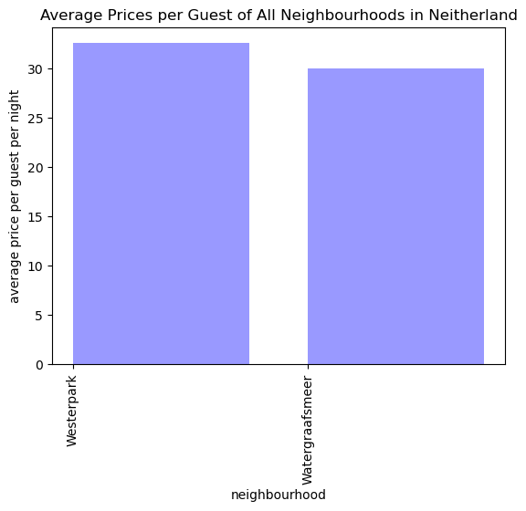

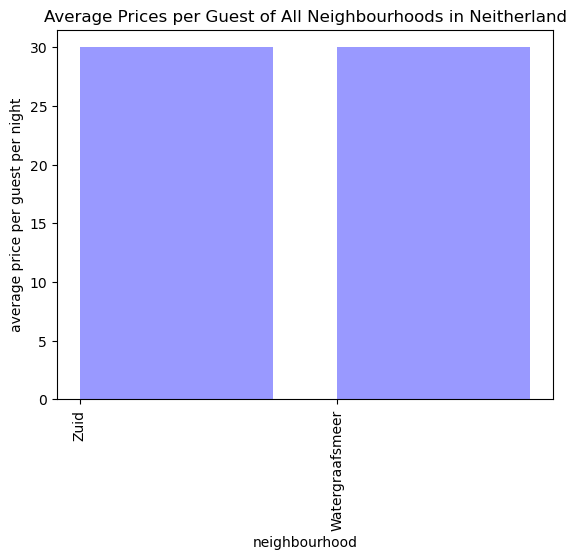

```
2 of 2 tests passed
2 of 2 tests passed
2 of 2 tests passed
2 of 2 tests passed
2 of 2 tests passed
2 of 2 tests passed
2 of 2 tests passed
1 of 1 tests passed
1 of 1 tests passed
1 of 1 tests passed
```

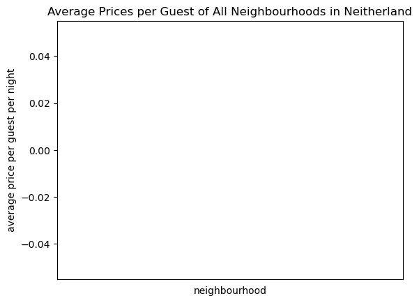

[output not shown]

```python
# tests for produce_num_sequence
expect(produce_num_sequence([], 5, 10), [])
expect(produce_num_sequence([1, 10, 3], 5, 10), [5, 15, 25])
expect(produce_num_sequence([1, 10, 3], 0.5, 3.5), [0.5, 4.0, 7.5])
summary()
```

[output not shown]

### Final Graph/Chart

Now that everything is working, you **must** call `main` on the intended information source in order to display the final graph/chart:

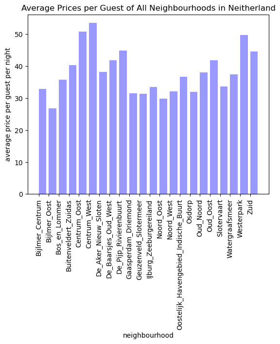

```python
main('airbnb_cleaned.csv', neighbourhoods)
```

```python
# Be sure to select ALL THE FILES YOU NEED (including csv's)
# when you submit. As usual, you cannot edit this cell.
# Instead, run this cell to start the submission process.
from cs103 import submit

COURSE = 101855
ASSIGNMENT = 1291659 # Final submission

submit(COURSE, ASSIGNMENT)

# If your submission fails, SUBMIT by downloading your files and uploading them
# to Canvas. You can learn how on the page "How to submit your Jupyter notebook"
# on our Canvas site.
```

# Please double check your submission on Canvas to ensure that the right files (Jupyter file + CSVs) have been submitted and that the files do not contain unexpected errors.

**You should always check your submission on Canvas. It is your responsibility to ensure that the correct file has been submitted for grading.** Regrade or accomodation requests using reasoning such as "I didn't realize I submitted the wrong file"/"I didn't realize the submission didn't work"/"I didn't realize I didn't save before submitting so some of my work is missing" will not be considered.